# Untitled

Gianluca Scuri

2022-11-28

# Domanda 1

## Setup e loading dataset

```r
# SETTING PROGETTO -------------------------------------------------------------

set.seed(100)

# Setting librerie utili
# Package names
packages <- c("KFAS", "xts", "readxl", "fastDummies")

# Install packages if not yet installed
installed_packages <- packages %in% rownames(installed.packages())
if (any(installed_packages == FALSE)) {
  install.packages(packages[!installed_packages])
}

# Packages loading
invisible(lapply(packages, library, character.only = TRUE))
working_dir = dirname(rstudioapi::getSourceEditorContext()$path)
setwd(working_dir) # lo applica solo a questo chunk!

precovid1 <- read.csv("../Dati ristoranti/pre-covid_r1.csv", row.names = 1)
fest_pre <- read_xlsx("../Dati aggiuntivi/fest_precovid.xlsx")
```

```r
# MAPE
mape <- function(actual,pred){
  mape <- mean(abs((actual - pred)/actual))*100
  return (mape)
}

#MSE
rmse <- function(actual, pred){
  rmse <- sqrt(mean((actual - pred)^2))
  return (rmse)
}
```

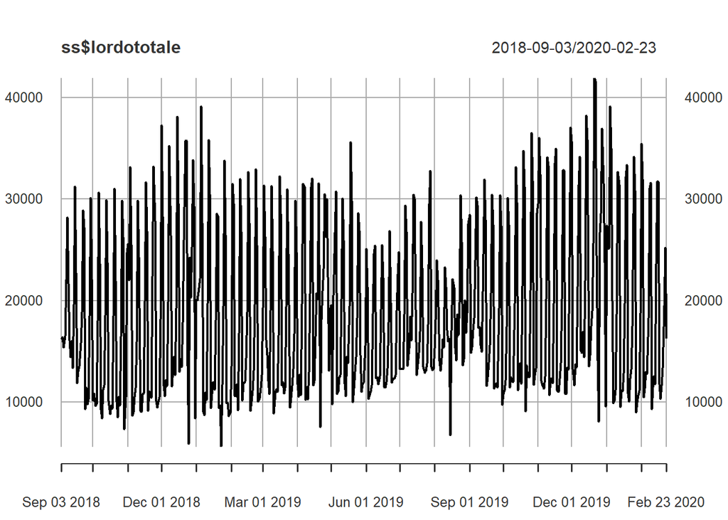

```r
prova <- precovid1[, c(8,14,15)]
prova$Weekend <- as.integer(as.logical(prova$Weekend))
prova$Festivo <- as.integer(as.logical(prova$Festivo))
ss <- xts(prova,
            as.Date(as.character(precovid1$data),
                    format = "%Y-%m-%d"))
plot(ss$lordototale)
```

Splitting e imputazione del validation set a NA

```r
train_date <- nrow(ss) *0.8
# Val è la serie intera
val <- ss[1:train_date,]
test <- ss[-c(1:train_date),] # Usare alla fine

# Data di fine del train
validation_date <- nrow(val) *0.9
train <- val
# Quindi train include i dati di training e un insieme di dati di test (NA)
# I regressori invece non sono impostati a NA
train$lordototale[validation_date:nrow(val),] <- NA
```

## Modello 1 (trend + stag7_d + stag365_10arm)

Definizione del modello, no train.

- Voglio stimare il log di lordo totale

- Le componenti che lo stimano sono Local Linear Trend, Stagionalità 7 giorni, Stagionalità 365

- NA è per quelle cose che vanno stimate - Sia che la definizione del modello, questo oggetto contiene anche i dati e i regressioni

```r
mod1 <- SSModel(log(lordototale+10)~
                  SSMtrend(2, list(NA, NA))+
                  SSMseasonal(7, NA)+
                  SSMseasonal(365, NA, "trigonometric", harmonics = 1:10),
                H=NA,
                data=train)
```

Assegna i valori iniziali ai parametri, parte da 0.

```r
mod1$P1inf[] <- 0 # no componenti diffuse
mod1$a1[1] <- mean(log(train$lordototale[1:50])) # scelta basata sui valori del primo mese

# Varianza della serie storica, utilizzata sotto per dare un ordine di grandezza
vy <- var(log(train$lordototale[1:50])) # calcoliamo la varianza
diag(mod1$P1) <- vy*10 # specifichiamo che abbiamo molta incertezza sui valori che abbiamo specificato
```

Inizializzazione delle varianze sulla base di vy

```r
pars <- log(c(
  logVarEta = vy/10,
  logVarZeta = vy/1000,
  logVarOm7 = vy/1000,
  logVarOm365 = vy/10000,
  logVarEps = vy/10
))
```

Definita funzione di update

```r
updt1 <- function(pars, model){
  model$Q[1,1,1] <- exp(pars[1])
  model$Q[2,2,1] <- exp(pars[2])
  model$Q[3,3,1] <- exp(pars[3])
  diag(model$Q[4:23, 4:23, 1]) <- exp(pars[4])
  model$H[1,1,1] <- exp(pars[5])
  model
}
```

Train - Si allena sui valori passati (quindi quei valori di train non nulli) - Train è in mod1

```r
fit1 <- fitSSM(mod1, pars, updt1)
fit1$optim.out
```

```
## $par
##   logVarEta  logVarZeta   logVarOm7 logVarOm365   logVarEps
##  -20.736703  -99.359684   -8.243798  -63.088069   -3.398741
##
## $value
## [1] 21.89047
##
## $counts
## function gradient
##      360       NA
##
## $convergence
## [1] 0
##
## $message
## NULL
```

Filtro di karman - Effetua le predizioni - kfs1$muhat contiene una serie storica predetta (anche i dati di train sono predetti)

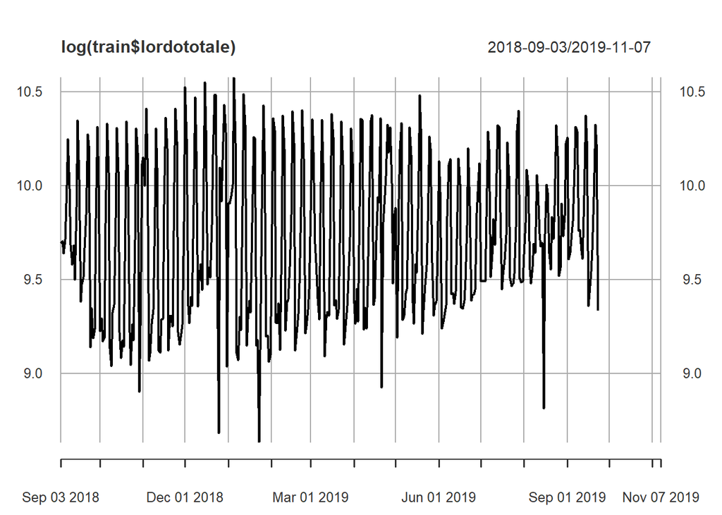

```r
# Filtro di karman
kfs1 <- KFS(fit1$model,
            smoothing = c("state", "signal", "disturbance"))

# Togli (plot del local linear trend, alphahat)
alphahat <- xts(as.matrix(kfs1$alphahat),
                index(train))
alphahat <- as.xts(alphahat)

plot(log(train$lordototale))
```

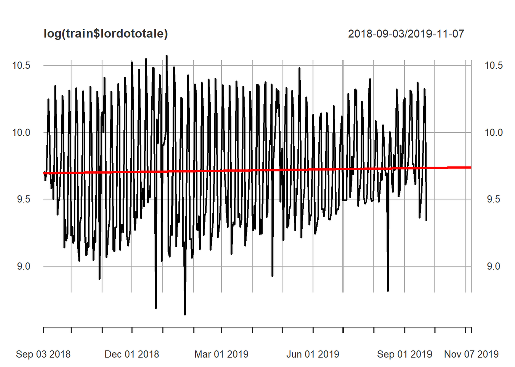

```r
lines(alphahat[, "level"], col = "red", lwd = 3)
```

```r
# Togli fino a qui
```

Conversione di muhat1 (serie storica predetta) -> previsioni del modello1

```r
# Togli plot validation dato vero
plot(log(val$lordototale[validation_date:nrow(val),]), lwd=3)
```

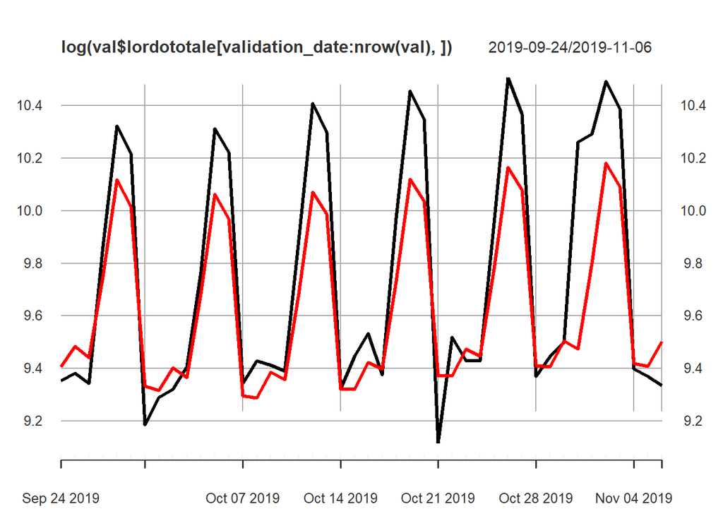

```r
# Questo tieni
muhat1 <- xts(as.matrix(kfs1$muhat),
                index(train))
muhat1 <- as.xts(muhat1)
# Prendi questa parte: muhat1[validation_date:nrow(val) per la selezione del validation

# Togli Plot delle predizioni muhat1
lines(muhat1[validation_date:nrow(val),], type = "l", col = "red", lwd=3) # [1801:1826,]
```

Da qui in poi faccio io

```r
mape(val$lordototale[validation_date:nrow(val),], exp(muhat1[validation_date:nrow(val),]))
```

```
## [1] 14.88535
```

```r
rmse(val$lordototale[validation_date:nrow(val),], exp(muhat1[validation_date:nrow(val),]))
```

```
## [1] 5341.25
```

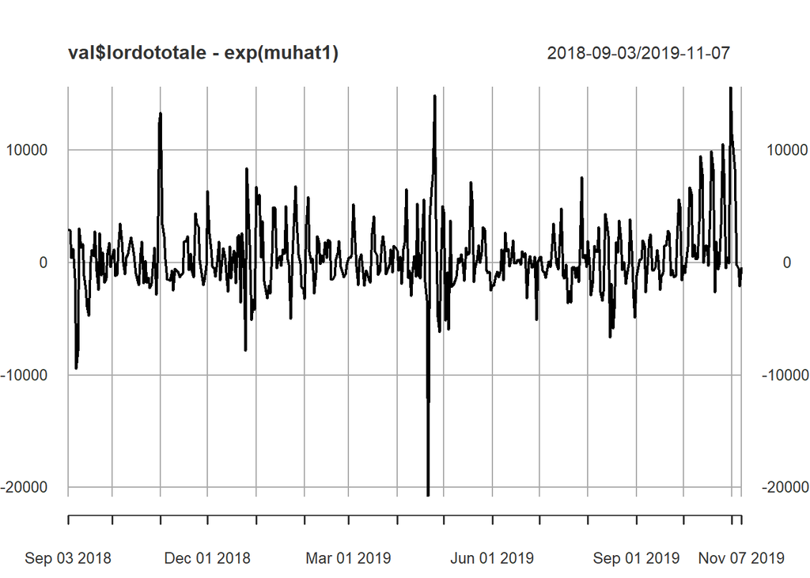

```r
plot(val$lordototale - exp(muhat1))
```

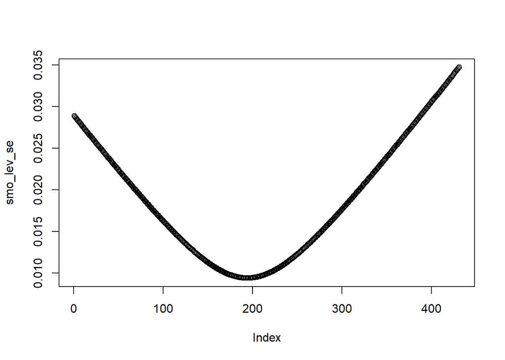

```r
smo_lev_se <- sqrt(kfs1$V[1,1,])
plot(smo_lev_se)
```

## Modello 2 (trend + stag7_d + stag365_10arm + weekend + festivo)

Aggiunta di due regressori

```r
mod2 <- SSModel(log(lordototale+10)~Weekend + Festivo +
                  SSMtrend(2, list(NA, NA))+
                  SSMseasonal(7, NA)+
                  SSMseasonal(365, NA, "trigonometric", harmonics = 1:10),
                H=NA,
                data=train)

mod2$P1inf[] <- 0 # no componenti diffuse
mod2$a1[1] <- mean(log(train$lordototale[1:50])) # scelta basata sui valori del primo mese

diag(mod2$P1) <- vy*10 # specifichiamo che abbiamo molta incertezza sui valori che abbiamo specificato

fit2 <- fitSSM(mod2, pars, updt1)
fit2$optim.out
```

```
## $par
##   logVarEta  logVarZeta   logVarOm7 logVarOm365   logVarEps
##   -6.606100  -10.558486   -8.146106  -20.805442   -3.496954
##
## $value
## [1] 53.33717
##
## $counts
## function gradient
##      214       NA
##
## $convergence
## [1] 0
##
## $message
## NULL
```

```r
kfs2 <- KFS(fit2$model,
            smoothing = c("state", "signal", "disturbance"))


plot(log(val$lordototale[validation_date:nrow(val),]), lwd=3)
```

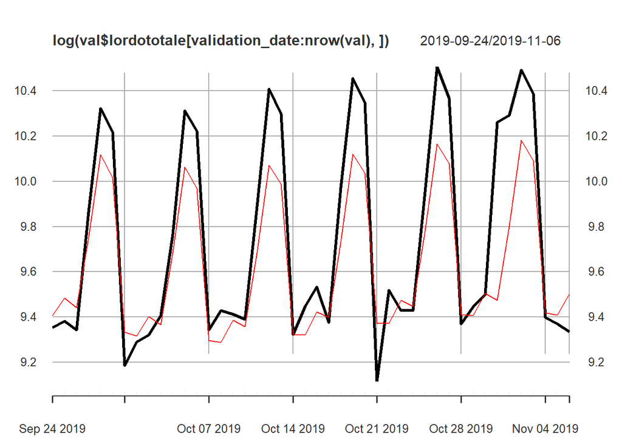

```r
muhat2 <- xts(as.matrix(kfs2$muhat),
                index(train))
muhat2 <- as.xts(muhat2)
lines(muhat1[validation_date:nrow(val),], type = "l", col = "red") # [1801:1826,]
```

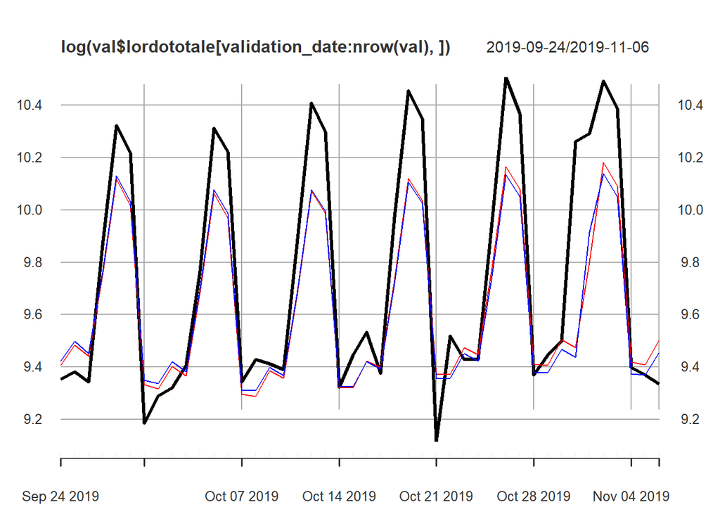

```r
lines(muhat2[validation_date:nrow(val),], type = "l", col = "blue") # [1801:1826,]
```

```r
mape(val$lordototale[validation_date:nrow(val),], exp(muhat2[validation_date:nrow(val),]))
```

```
## [1] 14.6955
```

```r
rmse(val$lordototale[validation_date:nrow(val),], exp(muhat2[validation_date:nrow(val),]))
```

```
## [1] 5406.625
```

## Modello 3 (trend + stag7_t + weekend + festivo)

```r
mod3 <- SSModel(log(lordototale+10)~Weekend + Festivo +
                  SSMtrend(2, list(NA, NA))+
                  SSMseasonal(7, NA, 'trigonometric'),
                H=NA,
                data=train)

updt3 <- function(pars, model){
  model$Q[1,1,1] <- exp(pars[1])
  model$Q[2,2,1] <- exp(pars[2])
  model$Q[3,3,1] <- exp(pars[3])
  diag(model$Q[4:8, 4:8, 1]) <- exp(pars[4])
  model$H[1,1,1] <- exp(pars[5])
  model
}

mod3$P1inf[] <- 0 # no componenti diffuse
mod3$a1[1] <- mean(log(train$lordototale[1:50])) # scelta basata sui valori del primo mese

diag(mod3$P1) <- vy*10 # specifichiamo che abbiamo molta incertezza sui valori che abbiamo specificato

fit3 <- fitSSM(mod3, pars, updt3)
fit3$optim.out
```

```
## $par
##   logVarEta  logVarZeta   logVarOm7 logVarOm365   logVarEps
##   -7.091738  -29.199329   -6.798766  -45.094219   -3.685183
##
## $value
## [1] -35.21464
##
## $counts
## function gradient
##      436       NA
##
## $convergence
## [1] 0
##
## $message
## NULL
```

```r
kfs3 <- KFS(fit3$model,
            smoothing = c("state", "signal", "disturbance"))


plot(log(val$lordototale[validation_date:nrow(val),]), lwd=3)
```

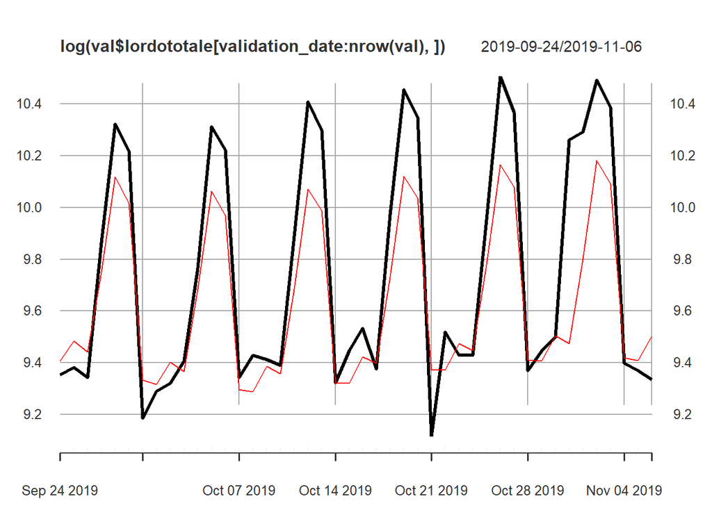

```r
muhat3 <- xts(as.matrix(kfs3$muhat),
                index(train))
muhat3 <- as.xts(muhat3)
lines(muhat1[validation_date:nrow(val),], type = "l", col = "red") # [1801:1826,]
```

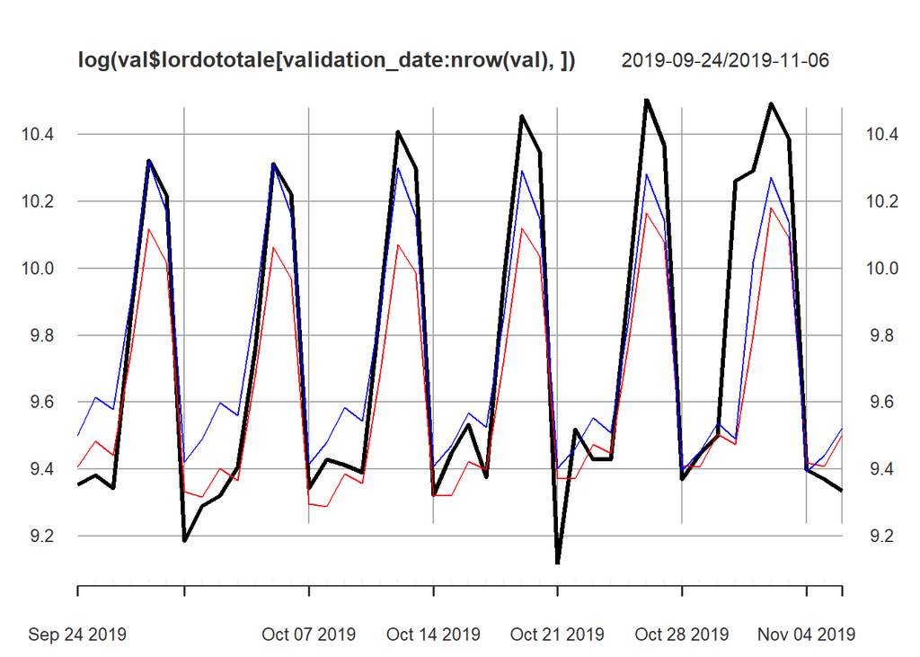

```r
lines(muhat3[validation_date:nrow(val),], type = "l", col = "blue") # [1801:1826,]
```

```r
mape(val$lordototale[validation_date:nrow(val),], exp(muhat3[validation_date:nrow(val),]))
```

```
## [1] 13.86368
```

```r
rmse(val$lordototale[validation_date:nrow(val),], exp(muhat3[validation_date:nrow(val),]))
```

```
## [1] 3929.418
```

## Modello 4 (trend + stag7_t + festivo)

```r
mod4 <- SSModel(log(lordototale+10)~Festivo + #Weekend +
                  SSMtrend(2, list(NA, NA))+
                  SSMseasonal(7, NA, "trigonometric"),
                  # SSMseasonal(365, NA, "trigonometric", harmonics = 1:10),
                H=NA,
                data=train)

updt4 <- function(pars, model){
  model$Q[1,1,1] <- exp(pars[1])
  model$Q[2,2,1] <- exp(pars[2])
  model$Q[3,3,1] <- exp(pars[3])
  diag(model$Q[4:8, 4:8, 1]) <- exp(pars[4])
  model$H[1,1,1] <- exp(pars[5])
  model
}

mod4$P1inf[] <- 0 # no componenti diffuse
mod4$a1[1] <- mean(log(train$lordototale[1:50])) # scelta basata sui valori del primo mese

diag(mod4$P1) <- vy*10 # specifichiamo che abbiamo molta incertezza sui valori che abbiamo specificato

fit4 <- fitSSM(mod4, pars, updt4)
fit4$optim.out
```

```
## $par
##   logVarEta  logVarZeta   logVarOm7 logVarOm365   logVarEps
##   -7.102942  -25.076832   -6.707732  -13.160792   -3.708168
##
## $value
## [1] -1.322567
##
## $counts
## function gradient
##      502       NA
##
## $convergence
## [1] 1
##
## $message
## NULL
```

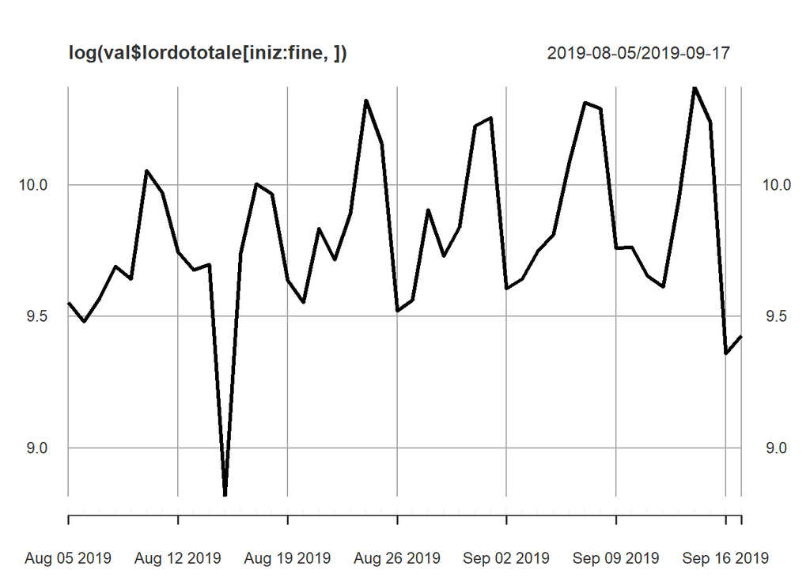

```r
kfs4 <- KFS(fit4$model,
            smoothing = c("state", "signal", "disturbance"))

# Togli
iniz <- validation_date -50
fine <- nrow(val) -50

plot(log(val$lordototale[iniz:fine,]), lwd=3)
```

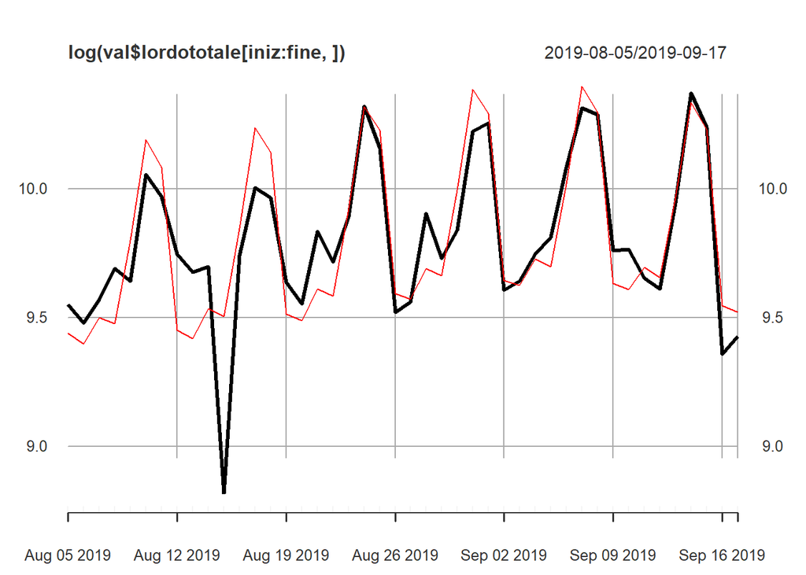

```r
# Togli fino a qui

muhat4 <- xts(as.matrix(kfs4$muhat),
                index(train))
muhat4 <- as.xts(muhat4)
lines(muhat1[iniz:fine,], type = "l", col = "red") # [1801:1826,]
```

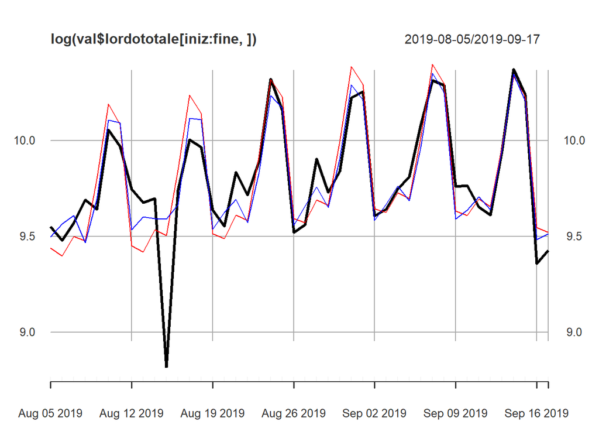

```r
lines(muhat4[iniz:fine,], type = "l", col = "blue") # [1801:1826,]
```

```r
mape(val$lordototale[validation_date:nrow(val),], exp(muhat4[validation_date:nrow(val),]))
```

```
## [1] 13.7521
```

```r
rmse(val$lordototale[validation_date:nrow(val),], exp(muhat4[validation_date:nrow(val),]))
```

```
## [1] 3942.077
```

## Modello 5 (trend + stag7_t + fest_precovid)

Processing, ottenimento di prova, il dataset che contiene serie storica e regressori - Da inserire

```r
# Processing fuori la funzione
temp <- dummy_cols(precovid1[10], select_columns = c("Giorno"),
                      remove_first_dummy = TRUE,
                      remove_selected_columns = TRUE)

prova <- cbind(precovid1[, c(8)], fest_pre[,-1], temp)
# prova[,2] <- as.integer(as.logical(prova[,2]))
# prova <- merge(x=precovid1[, c(8)], y=fest_pre[,-1], by.x=precovid1$data, by.y=fest_pre$date)

ss <- xts(prova,
            as.Date(as.character(precovid1$data),
                    format = "%Y-%m-%d"))

colnames(ss)[1] <- "lordototale"
ss$lordototale <- as.numeric(ss$lordototale)

# Processing dentro la funzione
train_date <- nrow(ss) * 0.8
val <- ss[1:train_date,]
test <- ss[-c(1:train_date),] # Usare alla fine

validation_date <- nrow(val) * 0.9
train <- val
train$lordototale[as.integer(validation_date+1):nrow(val),] <- NA
```

```r
mod5 <- SSModel(log(lordototale)~dec8+dec24+dec25+dec26+jan1+jan6+aug15+dec31+eastsun+eastermon+apr25+mag1+jun2+oct31+nov1+martgrasso+#bridge+#Giorno_Monday+Giorno_Tuesday+Giorno_Wednesday+Giorno_Thursday+Giorno_Saturday+Giorno_Sunday+
                  SSMtrend(2, list(NA, NA))+
                  SSMseasonal(7, NA, 'trigonometric'),
                H=NA,
                data=train)

updt5 <- function(pars, model){
  model$Q[1,1,1] <- exp(pars[1])
  model$Q[2,2,1] <- exp(pars[2])
  model$Q[3,3,1] <- exp(pars[3])
  diag(model$Q[4:8, 4:8, 1]) <- exp(pars[4])
  model$H[1,1,1] <- exp(pars[5])
  model
}

mod5$P1inf[] <- 0 # no componenti diffuse
mod5$a1[1] <- mean(log(train$lordototale[1:50])) # scelta basata sui valori del primo mese

diag(mod5$P1) <- vy*10 # specifichiamo che abbiamo molta incertezza sui valori che abbiamo specificato

fit5 <- fitSSM(mod5, pars, updt5)
fit5$optim.out
```

```
## $par
##   logVarEta  logVarZeta   logVarOm7 logVarOm365   logVarEps
##   -6.698622  -23.636461   -6.842285  -11.844752   -4.613479
##
## $value
## [1] -89.3304
##
## $counts
## function gradient
##      502       NA
##
## $convergence
## [1] 1
##
## $message
## NULL
```

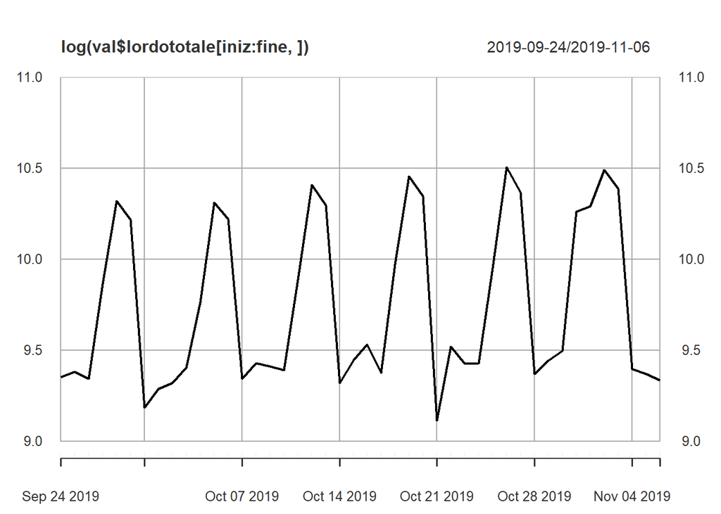

```r
kfs5 <- KFS(fit5$model,
            smoothing = c("state", "signal", "disturbance"))


iniz <- validation_date
fine <- nrow(val)

plot(log(val$lordototale[iniz:fine,]), lwd=2, ylim=c(9,11))
```

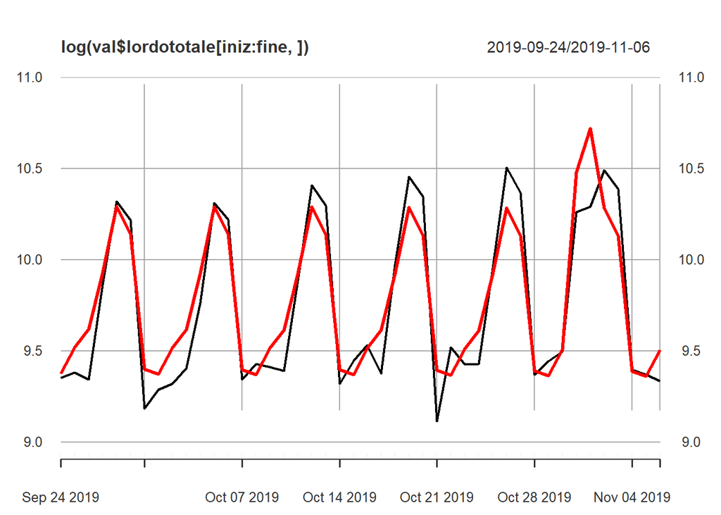

```r
muhat5 <- xts(as.matrix(kfs5$muhat),
                index(train))
muhat5 <- as.xts(muhat5)
#lines(muhat1[iniz:fine,], type = "l", col = "red") # [1801:1826,]
lines(muhat5[iniz:fine,], type = "l", col = "red", lwd=3) # [1801:1826,]
```

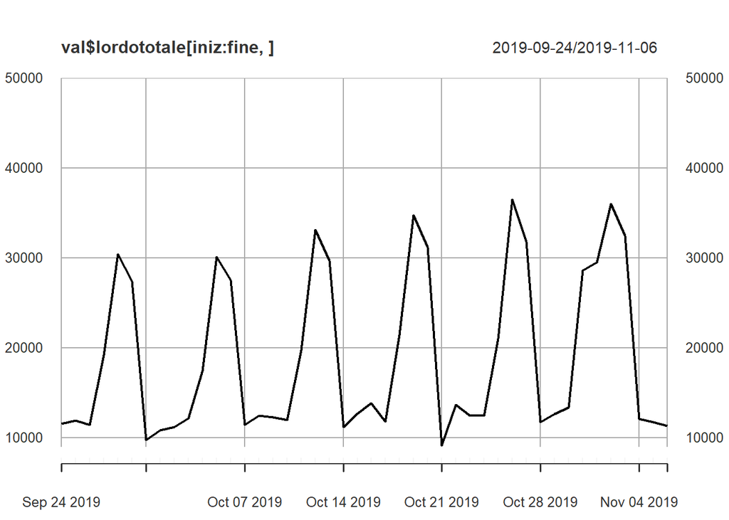

```r
plot(val$lordototale[iniz:fine,], lwd=2, ylim=c(9000,50000))
```

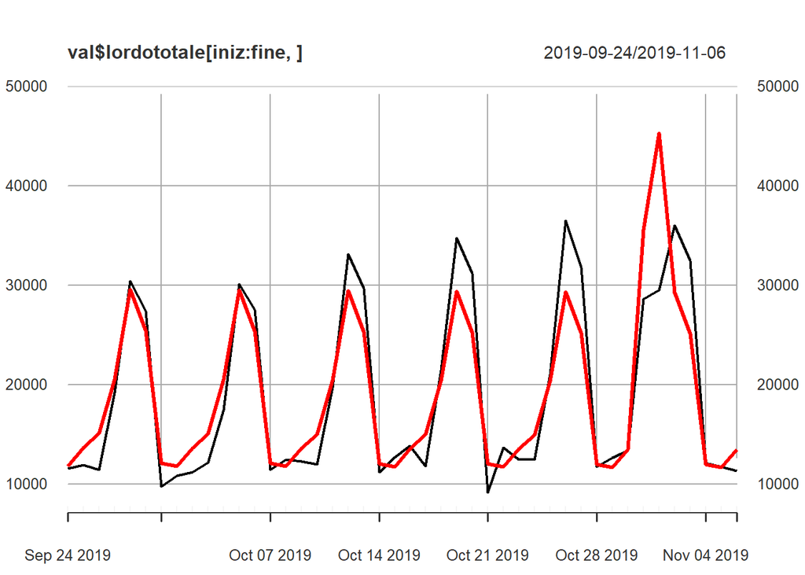

```r
lines(exp(muhat5[iniz:fine,]), type = "l", col = "red", lwd=3) # [1801:1826,]
```

```r
mape(val$lordototale[validation_date:nrow(val),], exp(muhat5[validation_date:nrow(val),]))
```

```
## [1] 13.68156
```

```r
rmse(val$lordototale[validation_date:nrow(val),], exp(muhat5[validation_date:nrow(val),]))
```

```
## [1] 3988.845
```

```r
summary(val$lordototale - exp(muhat5))
```

```
##      Index             lordototale
##  Min.   :2018-09-03   Min.   :-15792.03
##  1st Qu.:2018-12-19   1st Qu.:  -727.09
##  Median :2019-04-06   Median :   -30.98
##  Mean   :2019-04-06   Mean   :    83.56
##  3rd Qu.:2019-07-22   3rd Qu.:   774.68
##  Max.   :2019-11-07   Max.   :  7350.85
```

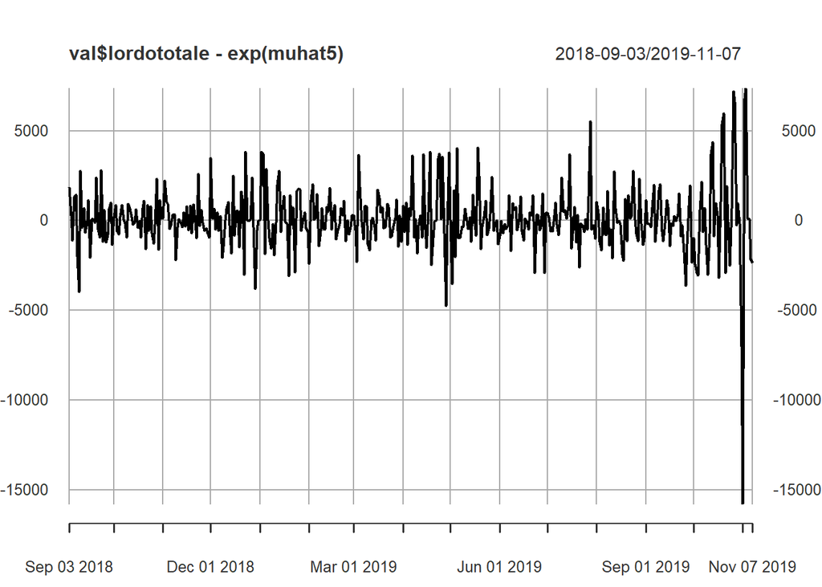

```r
plot(val$lordototale - exp(muhat5))
#abline(v=index(val[validation_date]))
abline(v=index(val[validation_date]))
```

```r
val[val$lordototale - exp(muhat5) <  -5000,]
```

```
##            lordototale dec8 dec24 dec25 dec26 dec31 jan1 jan6 apr25 mag1 jun2
## 2019-10-31    28626.94    0     0     0     0     0    0    0     0    0    0
## 2019-11-01    29518.80    0     0     0     0     0    0    0     0    0    0
##            aug15 oct31 nov1 eastsun eastermon martgrasso bridge Giorno_Monday
## 2019-10-31     0     1    0       0         0          0      0             0
## 2019-11-01     0     0    1       0         0          0      0             0
##            Giorno_Saturday Giorno_Sunday Giorno_Thursday Giorno_Tuesday
## 2019-10-31               0             0               1              0
## 2019-11-01               0             0               0              0
##            Giorno_Wednesday
## 2019-10-31                0
## 2019-11-01                0
```

## Confronto modelli

```r
comp <- data.frame(Modello=c("mod1", "mod2", "mod3", "mod4", "mod5"),
           RMSE=c(rmse(val$lordototale[validation_date:nrow(val),], exp(muhat1[validation_date:nrow(val),])),
                  rmse(val$lordototale[validation_date:nrow(val),], exp(muhat2[validation_date:nrow(val),])),
                  rmse(val$lordototale[validation_date:nrow(val),], exp(muhat3[validation_date:nrow(val),])),
                  rmse(val$lordototale[validation_date:nrow(val),], exp(muhat4[validation_date:nrow(val),])),
                  rmse(val$lordototale[validation_date:nrow(val),], exp(muhat5[validation_date:nrow(val),]))),
           MAPE=c(mape(val$lordototale[validation_date:nrow(val),], exp(muhat1[validation_date:nrow(val),])),
                  mape(val$lordototale[validation_date:nrow(val),], exp(muhat2[validation_date:nrow(val),])),
                  mape(val$lordototale[validation_date:nrow(val),], exp(muhat3[validation_date:nrow(val),])),
                  mape(val$lordototale[validation_date:nrow(val),], exp(muhat4[validation_date:nrow(val),])),
                  mape(val$lordototale[validation_date:nrow(val),], exp(muhat5[validation_date:nrow(val),]))))
comp
```

```
##   Modello     RMSE     MAPE
## 1    mod1 5341.250 14.88535
## 2    mod2 5406.625 14.69550
## 3    mod3 3929.418 13.86368
## 4    mod4 3942.077 13.75210
## 5    mod5 3988.845 13.68156
```

```r
pars_test <- function(coef, var_coef){
  test <- (1-pnorm(abs(coef)/sqrt(diag(var_coef))))*2
  return(test)
}
```

```r
mod6 <- SSModel(lordototale~dec8+dec24+dec25+dec26+jan1+jan6+aug15+dec31+eastsun+eastermon+apr25+mag1+jun2+oct31+nov1+martgrasso+#bridge+#Giorno_Monday+Giorno_Tuesday+Giorno_Wednesday+Giorno_Thursday+Giorno_Saturday+Giorno_Sunday+
                  SSMtrend(2, list(NA, NA))+
                  SSMseasonal(7, NA),
                H=NA,
                data=train)

updt6 <- function(pars, model){
  model$Q[1,1,1] <- pars[1]
  model$Q[2,2,1] <- pars[2]
  model$Q[3,3,1] <- pars[3]
  #un regressore che tdiag(model$Q[4:8, 4:8, 1]) <- pars[4]
  model$H[1,1,1] <- pars[5]
  model
}

mod6$P1inf[] <- 0 # no componenti diffuse
mod6$a1[1] <- mean(train$lordototale[1:50]) # scelta basata sui valori del primo mese

diag(mod6$P1) <- vy*10 # specifichiamo che abbiamo molta incertezza sui valori che abbiamo specificato

fit6 <- fitSSM(mod6, pars, updt6)
fit6$optim.out
```

```
## $par
##   logVarEta  logVarZeta   logVarOm7 logVarOm365   logVarEps
##   -4.091661   -8.696831   -8.696831  -10.999416   -4.091661
##
## $value
## [1] 1.552518e+231
##
## $counts
## function gradient
##        6       NA
##
## $convergence
## [1] 0
##
## $message
## NULL
```

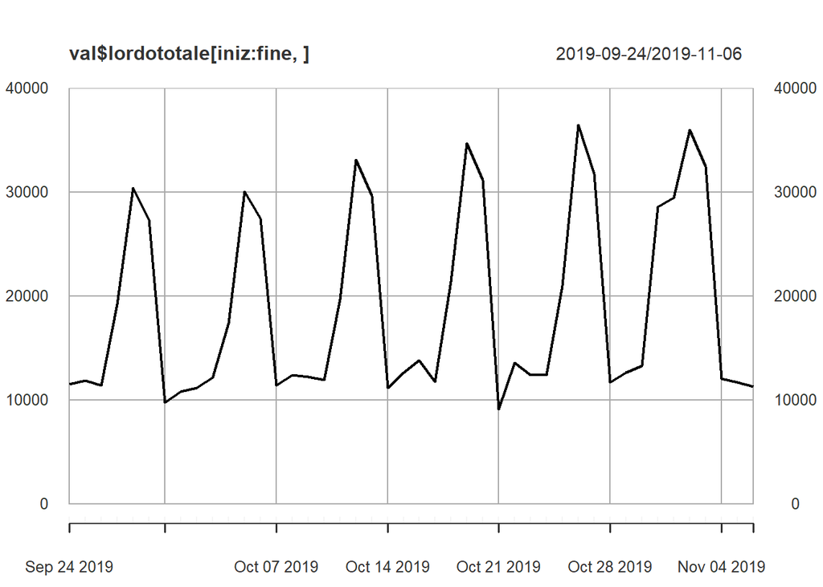

```r
kfs6 <- KFS(fit6$model,
            smoothing = c("state", "signal", "disturbance"))


iniz <- validation_date
fine <- nrow(val)

plot(val$lordototale[iniz:fine,], lwd=2, ylim = c(0, 40000))
```

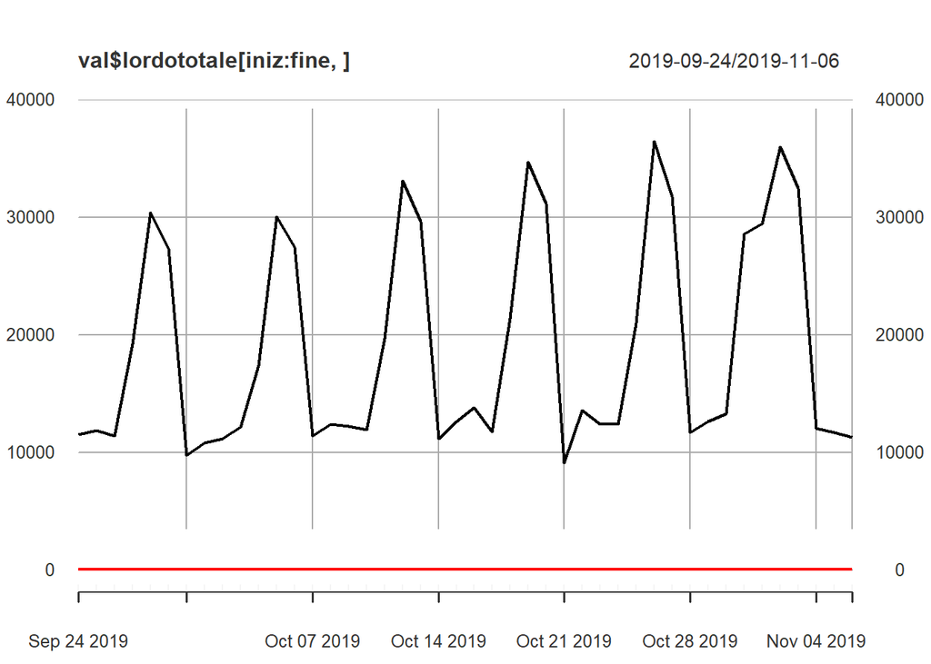

```r
muhat6 <- xts(as.matrix(kfs6$muhat),
                index(train))
muhat6 <- as.xts(muhat6)
#lines(muhat1[iniz:fine,], type = "l", col = "red") # [1801:1826,]
lines(muhat6[iniz:fine,], type = "l", col = "red", lwd=3) # [1801:1826,]
```